# Analysis of Hotel Prices In India

Prince Barai

February 22, 2018

**Analysis of Hotel Prices**

NAME: Prince Barai

EMAIL: princepratik7284@gmail.com

COLLEGE : University of Engineering & Management, Kolkata

**Setup The Working Directory and Make Sure This Package Are Already Installed**

```r
library(tidyr)
library(dplyr)
```

```r
library(ggplot2)
library(corrgram)
library(gridExtra)
library(vcd)
library(psych)
library(car)
library(corrplot)
```

**Functions**

```r
detect_outliers <- function(inp, na.rm=TRUE) {
  i.qnt <- quantile(inp, probs=c(.25, .75), na.rm=na.rm)
  i.max <- 1.5 * IQR(inp, na.rm=na.rm)
  otp <- inp
  otp[inp < (i.qnt[1] - i.max)] <- NA
  otp[inp > (i.qnt[2] + i.max)] <- NA
  #inp <- count(inp[is.na(otp)])
  sum(is.na(otp))
}

Non_outliers <- function(x, na.rm = TRUE, ...) {
  qnt <- quantile(x, probs=c(.25, .75), na.rm = na.rm, ...)
  H <- 1.5 * IQR(x, na.rm = na.rm)
  y <- x
  y[x < (qnt[1] - H)] <- NA
  y[x > (qnt[2] + H)] <- NA
  y
}

Remove_Outliers <- function ( z, na.rm = TRUE){
 Out <- Non_outliers(z)
 Out <-as.data.frame (Out)
 z <- Out$Out[match(z, Out$Out)]
 z
}

Graph_Boxplot <- function (input, na.rm = TRUE){
Plot <- ggplot(dfrModel, aes(x="", y=input)) +
            geom_boxplot(aes(fill=input), color="green") +
            labs(title="Outliers")
Plot
}
```

**Reading The DataSet**

```r
dfrModel <- read.csv("./Cities42.csv", header=T, stringsAsFactors=F)
```

**Visualizing The Length And Breadth of Dataset**

```r
View(dfrModel)
dim(dfrModel)
```

```
## [1] 13232    20
```

```r
intRowCount <- nrow(dfrModel)
head(dfrModel)
```

```
##   X CityName Population CityRank IsMetroCity IsTouristDestination
## 1 1   Mumbai   12442373        0           1                    1
## 2 2   Mumbai   12442373        0           1                    1
## 3 3   Mumbai   12442373        0           1                    1
## 4 4   Mumbai   12442373        0           1                    1
## 5 5   Mumbai   12442373        0           1                    1
## 6 6   Mumbai   12442373        0           1                    1
##   IsWeekend IsNewYearEve        Date      HotelName RoomRent StarRating
## 1         1            0 Dec 18 2016 Vivanta by Taj    12375          5
## 2         0            0 Dec 21 2016 Vivanta by Taj    10250          5
## 3         1            0 Dec 24 2016 Vivanta by Taj     9900          5
## 4         1            0 Dec 25 2016 Vivanta by Taj    10350          5
## 5         0            0 Dec 28 2016 Vivanta by Taj    12000          5
## 6         1            1 Dec 31 2016 Vivanta by Taj    11475          5
##   Airport                                 HotelAddress HotelPincode
```

[output cut: 20 more lines]

Observation I:

**Data Cleaning**

```r
dfrModel <- select(dfrModel, -c(CityName, Date, HotelName, HotelAddress, HotelDescription, HotelPincode ))
```

**Summary**

```r
describe(dfrModel$Population)[,c(2,3,4,5,8,9)]
```

```
##        n    mean      sd  median  min      max
## X1 13232 4416837 4258386 3046163 8096 12442373
```

```r
describe(dfrModel$StarRating)[,c(2,3,4,5,8,9)]
```

```
##        n mean   sd median min max
## X1 13232 3.46 0.76      3   0   5
```

```r
describe(dfrModel$StarRating)[,c(2,3,4,5,8,9)]
```

```
##        n mean   sd median min max
## X1 13232 3.46 0.76      3   0   5
```

```r
describe(dfrModel$HotelCapacity)[,c(2,3,4,5,8,9)]
```

```
##        n  mean    sd median min max
## X1 13232 62.51 76.66     34   0 600
```

**Observations**

Dependent Variable is Y = Hotel Rent

Independent Variable is X1 = Star Rating X2 = IsTouristDestination X3 = Airport Distance X4 = Hotel Capacity

**Creating Two Way Contigency Table**

```r
aggregate(dfrModel$RoomRent, by=list(weekend = dfrModel$IsWeekend, newyearseve = dfrModel$IsNewYearEve), mean)
```

```
##   weekend newyearseve        x
## 1       0           0 5429.473
## 2       1           0 5320.820
## 3       0           1 8829.500
## 4       1           1 6219.655
```

```r
aggregate(dfrModel$RoomRent, by=list(Metrocity = dfrModel$IsMetroCity, TouristPlace = dfrModel$IsTouristDestination), mean)
```

```
##   Metrocity TouristPlace        x
## 1         0            0 4006.435
## 2         1            0 4646.136
## 3         0            1 6755.728
## 4         1            1 4706.608
```

```r
aggregate(dfrModel$RoomRent, by=list(freewifi = dfrModel$FreeWifi, freeBreakfast = dfrModel$FreeBreakfast, swimmingPool = dfrModel$HasSwimmingPool), mean)
```

```
##   freewifi freeBreakfast swimmingPool        x
## 1        0             0            0 3538.085
## 2        1             0            0 3148.628
## 3        0             1            0 5636.617
## 4        1             1            0 3984.457
## 5        0             0            1 7378.590
## 6        1             0            1 9530.906
## 7        0             1            1 5207.000
## 8        1             1            1 8246.284
```

**Box Plot**

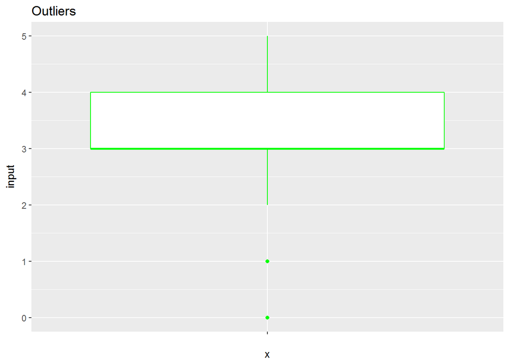

```r
Graph_Boxplot(dfrModel$StarRating)
```

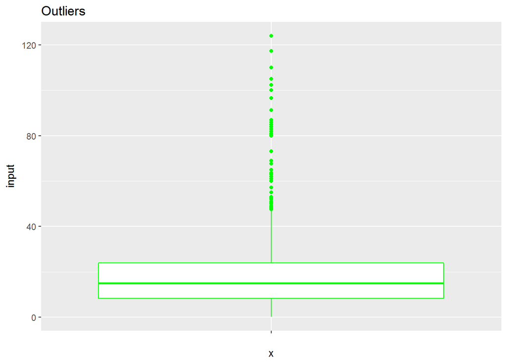

```r
Graph_Boxplot(dfrModel$Airport)
```

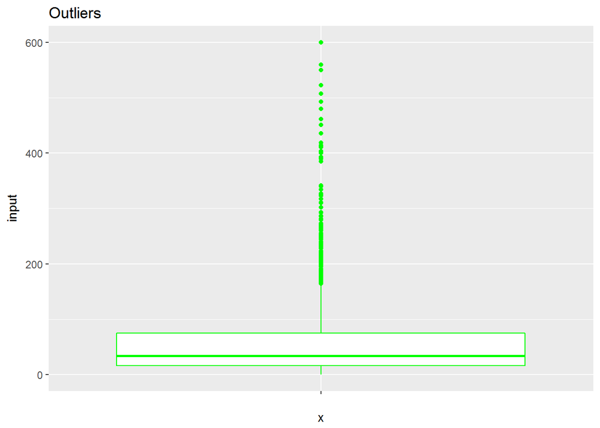

```r
Graph_Boxplot(dfrModel$HotelCapacity)
```

**Observations:**

**Drawing Coxplot and Comparing**

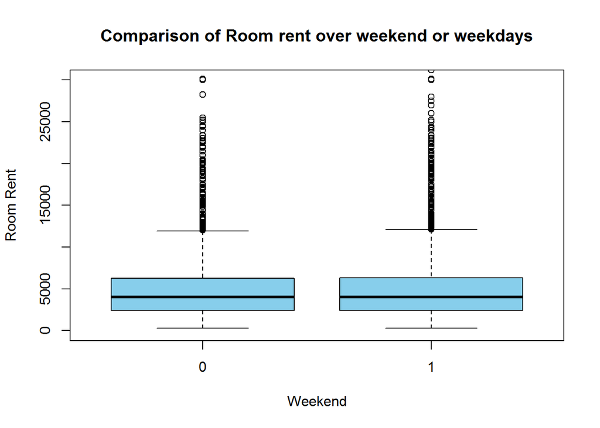

```r
boxplot(dfrModel$RoomRent ~ dfrModel$IsWeekend, xlab = "Weekend" , ylab = "Room Rent" , main = "Comparison of Room rent over weekend or weekdays", ylim = c(0,30000), col = "skyblue")
```

**Drawing Histogram**

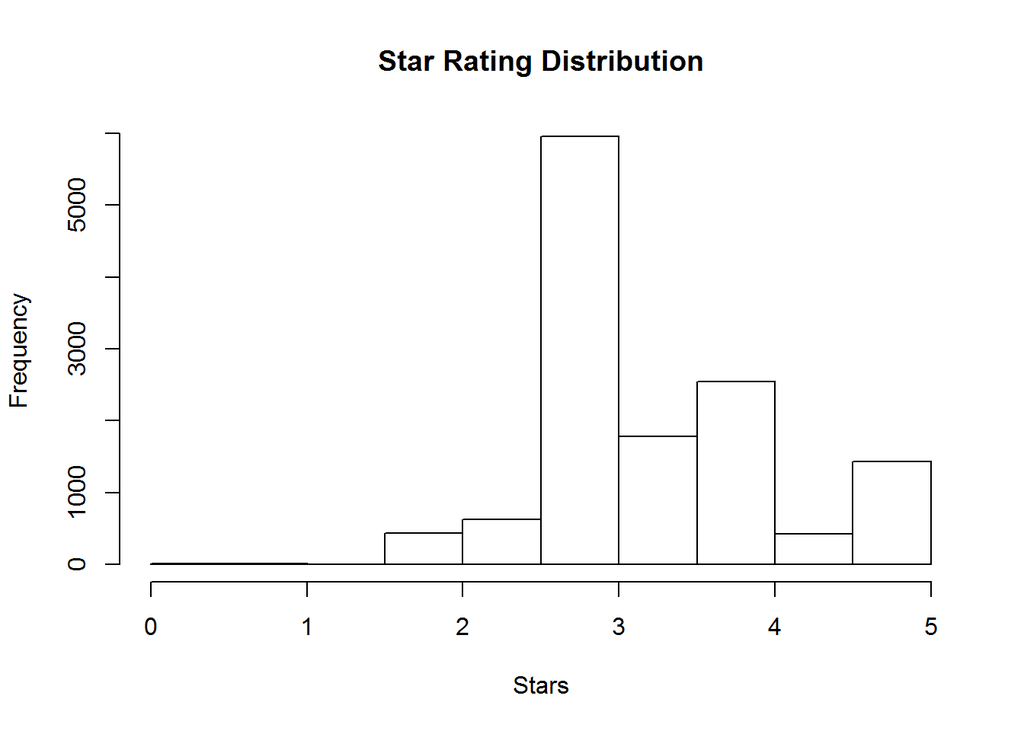

```r
hist(dfrModel$StarRating, main = "Star Rating Distribution", xlab = "Stars")
```

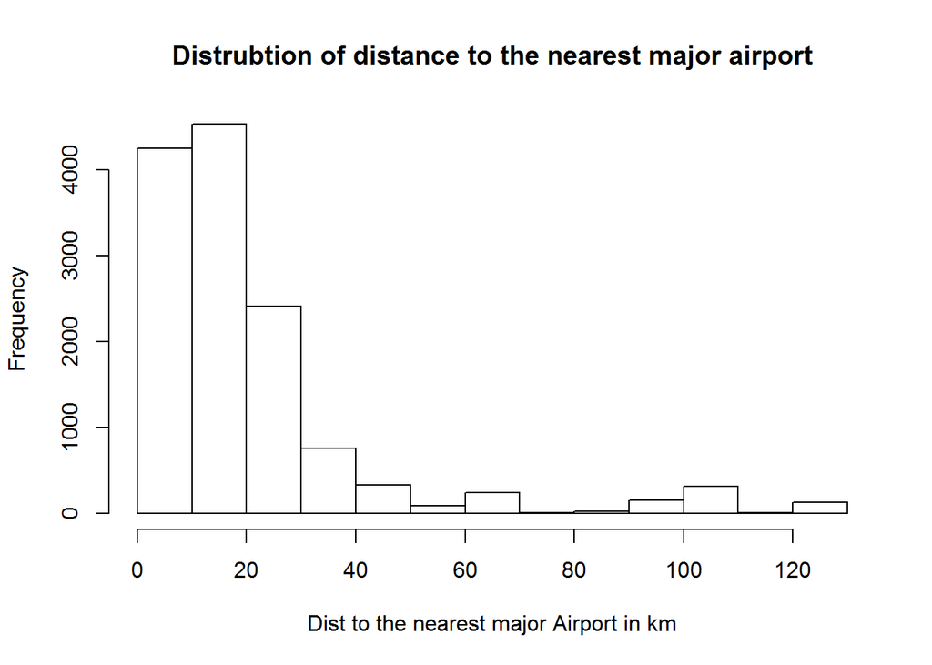

```r
hist(dfrModel$Airport, main = "Distrubtion of distance to the nearest major airport", xlab = "Dist to the nearest major Airport in km")
```

**Tables**

```r
TouristDestination <- table(dfrModel$IsTouristDestination)
TouristDestination
```

```
##
##    0    1
## 4007 9225
```

```r
prop.table(TouristDestination)
```

```
##
##         0         1
## 0.3028265 0.6971735
```

**Observations**

Here

1 Implies Tourist Destination 0 Implies Not an tourist destination

**Scatter Plot**

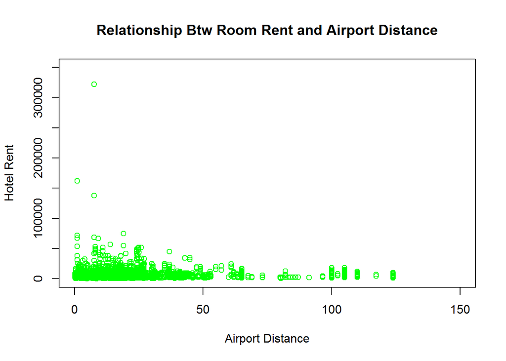

```r
plot(y=dfrModel$RoomRent, x=dfrModel$Airport,
     col="green",
     ylim=c(0, 350000), xlim=c(0, 150),
     main="Relationship Btw Room Rent and Airport Distance",
     ylab="Hotel Rent", xlab="Airport Distance")
```

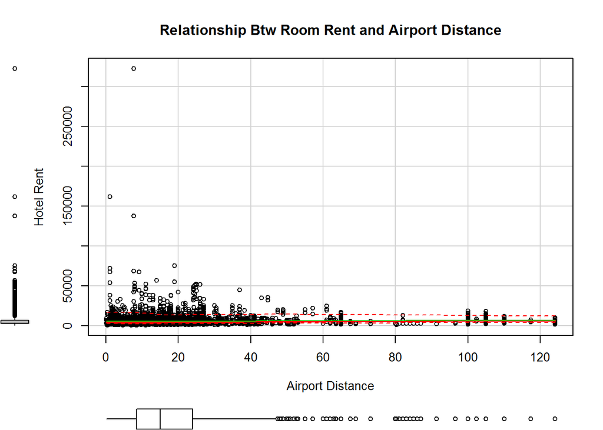

```r
scatterplot(dfrModel$Airport, dfrModel$RoomRent , main="Relationship Btw Room Rent and Airport Distance", xlab="Airport Distance", ylab="Hotel Rent")
```

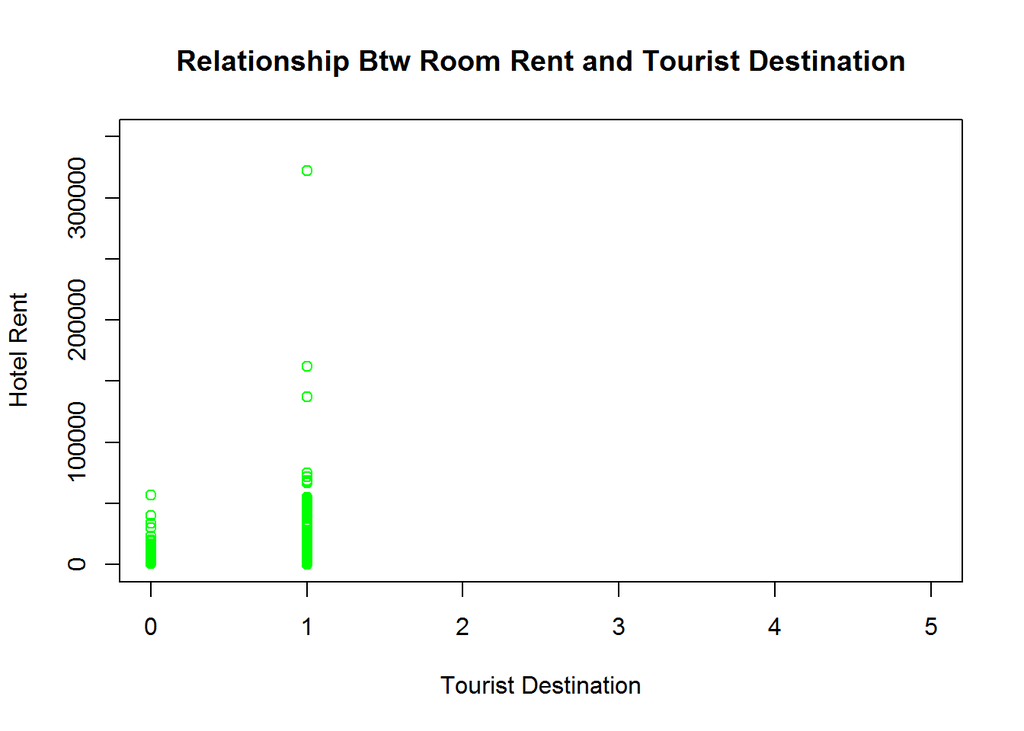

```r
plot((dfrModel$IsTouristDestination),jitter(dfrModel$RoomRent),
     col="green",
     ylim=c(0, 350000), xlim=c(0, 5),
     main="Relationship Btw Room Rent and Tourist Destination",
     ylab="Hotel Rent", xlab="Tourist Destination")
```

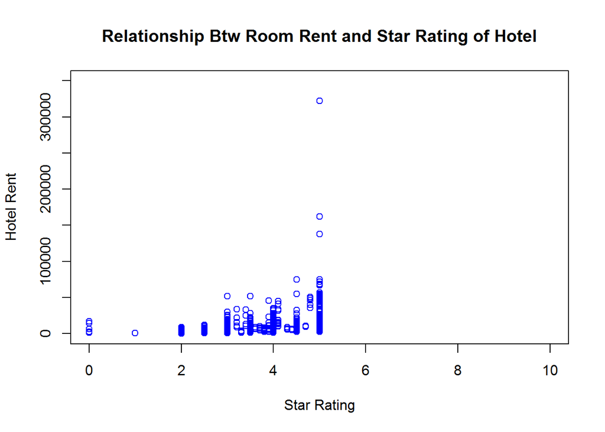

```r
plot(y=dfrModel$RoomRent, x=dfrModel$StarRating,
     col="blue",
     ylim=c(0, 350000), xlim=c(0, 10),
     main="Relationship Btw Room Rent and Star Rating of Hotel",
     ylab="Hotel Rent", xlab="Star Rating")
```

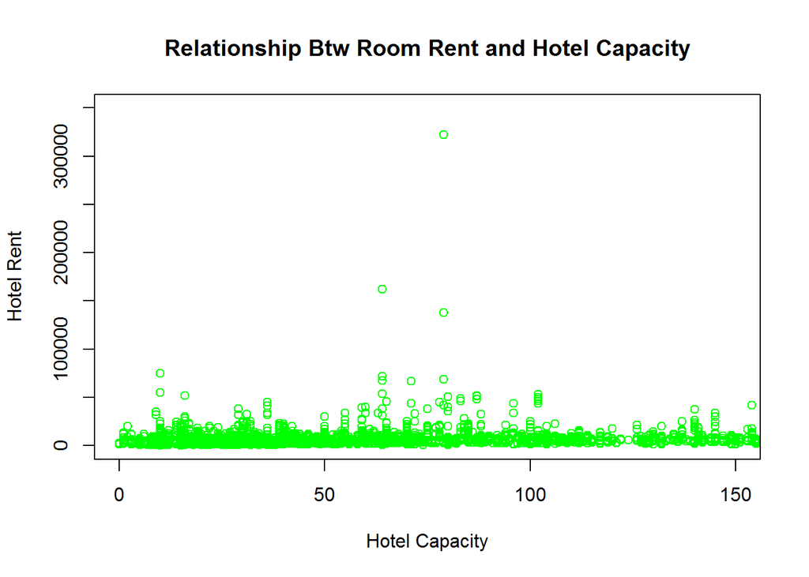

```r
plot(y=dfrModel$RoomRent, x=dfrModel$HotelCapacity,
     col="green",
     ylim=c(0, 350000), xlim=c(0, 150),
     main="Relationship Btw Room Rent and Hotel Capacity",
     ylab="Hotel Rent", xlab="Hotel Capacity")
```

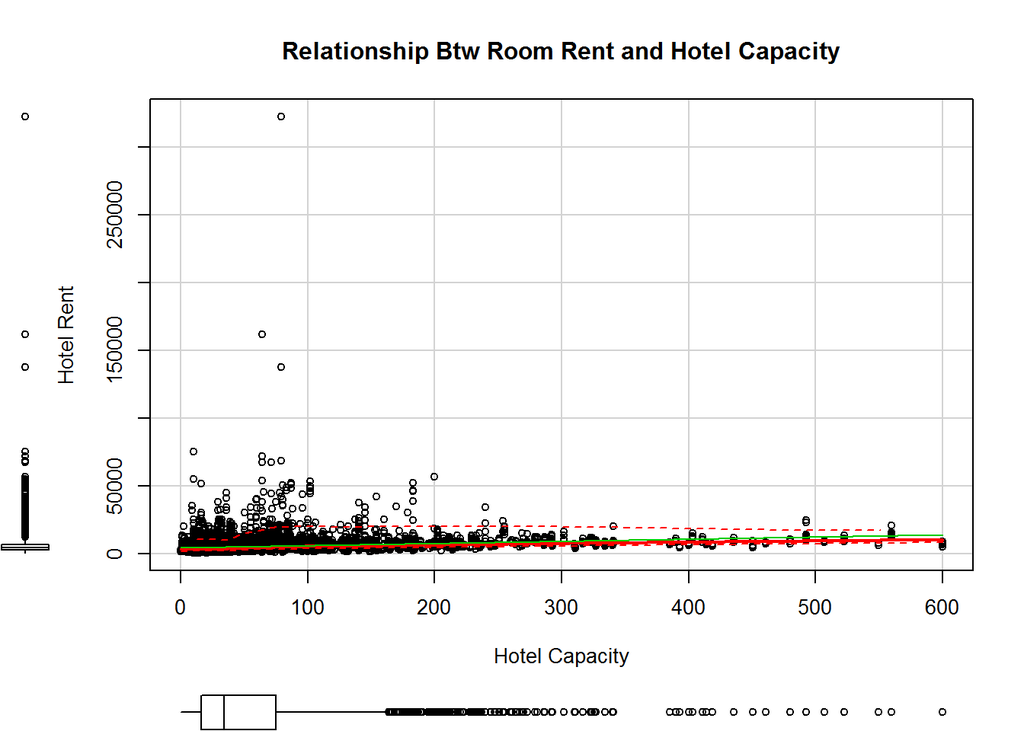

```r
scatterplot(dfrModel$HotelCapacity, dfrModel$RoomRent , main="Relationship Btw Room Rent and Hotel Capacity", xlab="Hotel Capacity", ylab="Hotel Rent")
```

**Observations**

1.Above scatter plot is showing some relationship between Hotel rent and other Independent variables.

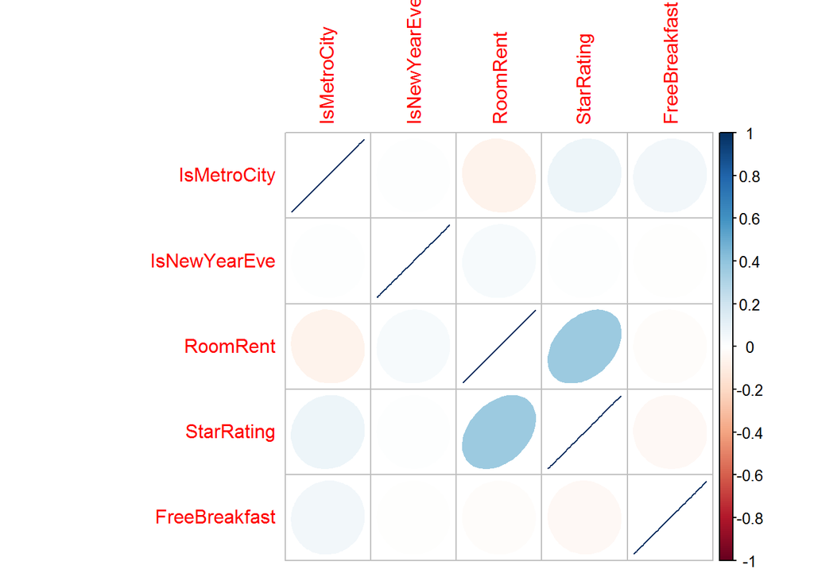

```r
corrplot(corr=cor(dfrModel[ , c(4,7,8,9,12)], use="complete.obs"),
         method ="ellipse")
```

**Correlation**

```r
cor(dfrModel[, c(4,7,8,9,12)])
```

```
##                 IsMetroCity  IsNewYearEve    RoomRent   StarRating
## IsMetroCity    1.0000000000  0.0006464753 -0.06683977  0.077602866
## IsNewYearEve   0.0006464753  1.0000000000  0.03849123  0.002360897
## RoomRent      -0.0668397705  0.0384912269  1.00000000  0.369373425
## StarRating     0.0776028661  0.0023608970  0.36937343  1.000000000
## FreeBreakfast  0.0513856623 -0.0026064156 -0.01000637 -0.032892463
##               FreeBreakfast
## IsMetroCity     0.051385662
## IsNewYearEve   -0.002606416
## RoomRent       -0.010006370
## StarRating     -0.032892463
## FreeBreakfast   1.000000000
```

**T-Test**

```r
t.test(dfrModel$RoomRent ~ dfrModel$IsNewYearEve)
```

```
##
##  Welch Two Sample t-test
##
## data:  dfrModel$RoomRent by dfrModel$IsNewYearEve
## t = -4.1793, df = 2065, p-value = 3.046e-05
## alternative hypothesis: true difference in means is not equal to 0
## 95 percent confidence interval:
##  -1256.5297  -453.9099
## sample estimates:
## mean in group 0 mean in group 1
##        5367.606        6222.826
```

From t-test that the P-Value = 3.046e-05 (<0.05) Which is small enough for Rejecting the Null Hupothesis. Hence there is impact on the room rents on New Year’s eve and on other days.

**Summary**

Data has been loaded successfully

Data has been summarized to know the different statistical values Outliers has been find out in each variable and Evry variable is plotted on Box plot to know about the outliers Dependent and Independent variable are find out. Dependent Variable is Y = Hotel Rent

Independent Variable is

X1 = Star Rating

X2 = IsTouristDestination

X3 = Airport Distance

X4 Can also be Hotel Capacity